# Dynamical Oceanography - VirtualShip Classroom

February/March 2026 | Utrecht University

[figure not shown]

- **VirtualShip** provides an authentic experience of oceanographic expeditions anywhere in the global ocean.
- As scientists, you will plan and execute an oceanographic expedition, analyse the resulting data and communicate your findings in a final presentation.

## Your expedition 🚢

- Congratulations on receiving a student research grant for ship time on a virtual scientific research vessel!
- As a group you will:
  - Have access to the ship for a *maximum* of three weeks and you can conduct your research anywhere in the global ocean.
  - Have access to a wide range of oceanographic instruments, including CTDs, ADCPs, Drifters, Argo floats, and more.
  - Be responsible for planning and executing your expedition.
    - Including submitting a proposal for your expedition, which will be reviewed by a panel of experts (i.e. the teachers).
  - Be expected to communicate your findings and experiences in a final presentation.
  - Write and submit a Code of Conduct for your group.

## The presentation

- As a group, you will create a slide-deck to present your expedition to the class and teachers.
- Your presentation should be 12 minutes long, and will be followed by a few minutes of Q&A.
- The grade (30% of the course) is based on the slides and presentation (rubric will be provided).
  - The group grade is the average of that by the lecturer, the two VSC teachers, and the average of the peer students.
  - How the grade is divided between group members is based on Code of Conduct.
- The presentation should include:
  - An introduction and motivation for your expedition.
  - A description of your expedition plan, what instruments you deployed and why.
  - A discussion of the challenges you faced during your expedition.
  - An analysis of your data, including computing derived quantities.
  - An animation of the data (in time and/or space).
  - A discussion of your findings.

## Timetable

| Session | Date | Objective(s) |
| --- | --- | --- |
| Tutorial 4 | 20 Feb | Code of Conduct, start expedition proposal, start trial run of VirtualShip |
| Tutorial 6 | 27 Feb | Begin your own expedition, 360° videos |
| Tutorial 7 | 4 March | Continue your expedition, analyse expedition results |
| Tutorial 8 | 6 March | Analyse expedition results |
| Tutorial 9 | 11 March | Presentation preparation |
| Tutorial 10 | 13 March | **Presentations** |

**Note**

Note, you are expected to work on your projects in your own time/outside of class as well.

## Deadlines

- **Code of Conduct**: 17:00 20th Feb
- **Expedition proposal**: 17:00 25th Feb
- **Upload presentation slides**: 17:00 12th March
- **Final presentations**: 13 March (Tutorial 10)

## Our request to you

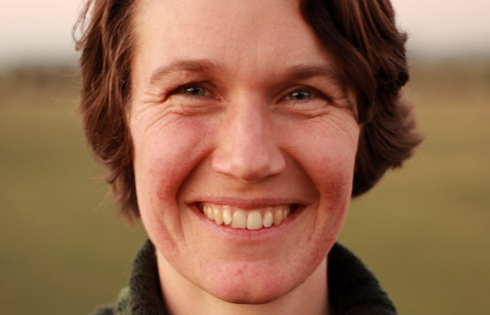

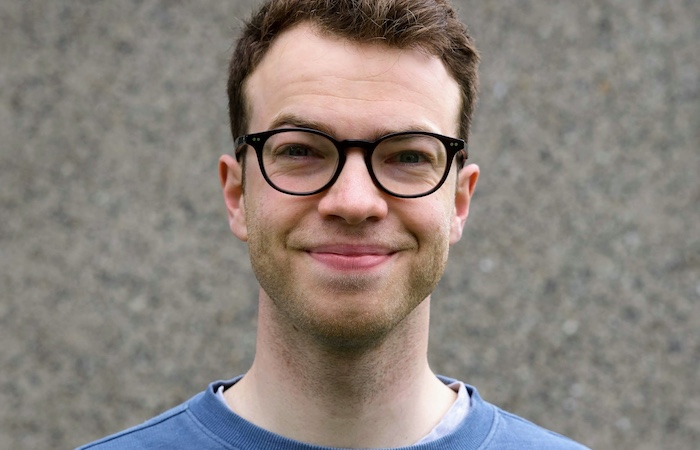

- We are developing the VirtualShip Classroom platform as part of a UU-NIOZ project.
- Emma and Jamie (VSC teachers) are Postdoctoral Researchers and will use your **feedback** to improve the platform and course for future implementations.
- We will ask you to please complete a **survey** at the end of the course, as well as invite you to participate in an **interview** at a later date.

## Tutorial 4 (20 Feb)

#### Today’s objectives

- Log in and set up virtual environment (SURF Research Cloud)
- Code of Conduct (remember, hand in by 17:00 today!)
- Choose region/topic of interest → start expedition proposal (due 17:00 25th Feb)
- Start trial run of VirtualShip (complete by 17:00 25th Feb)

**Tip**

You have a free afternoon on Wednesday 25 February to complete your trial run (and expedition proposal)!

*The relevant links to each of these components will be posted on **Brightspace***.

## Tutorial 6 (27 Feb)

#### Today’s objectives

- Using your expedition proposal, start your own expedition in VirtualShip!
  - MFP route planning
  - Schedule and instrument deployment planning
  - Execute your expedition simulation
- Explore the 360° videos of the ship and instruments.

*The relevant links to each of these components will be posted on **Brightspace***.